# Homework 1

Krista Noe

February 10, 2021

Use linear regression to determine how beach areas changes through time. The variables are:  
• BeachID: categorical variable, unique identification for each beach  
• Year: continuous variable, year the beach area was measured  
• OpenBeach: continuous variable, the area in hectares of open beach

1. Import the “beach.csv” dataset into R and examine the first few rows of data

```r
beach <- read.csv("beach.csv")
head(beach, 3)
```

```
##   BeachID Year OpenBeach
## 1       A 1992     437.8
## 2       A 1993     423.6
## 3       A 1994     333.1
```

2. Fit a model that includes interactions between Year and BeachID. Report estimates of all coefficients

```r
fit <- lm(OpenBeach ~ Year * BeachID, data = beach) #so you are predicting area of open beach (response variable), by both year and beach ID (predictor variables)

fit
```

```
##
## Call:
## lm(formula = OpenBeach ~ Year * BeachID, data = beach)
##
## Coefficients:
##   (Intercept)           Year       BeachIDB       BeachIDC  Year:BeachIDB
##      36945.73         -18.36      -34211.98      -28776.11          17.04
## Year:BeachIDC
##         14.37
```

3. Predict the beach area at all three beaches in 1992

```r
# interactive model: y = B0 + (B1*X1) + (B2*X2) + (B3*X1*X2)
# can be rewritten as: y = B0 + (B1+B3)*X1 + B2

a <- 36945.73 + (- 18.36 * 1992)
  # this equation can be written as y = B0 + (B1 * X1) since the other terms equal 0
  # B0 = 36945.73
  # B1 = -18.36
  # X1 = 1992

b <- 36945.73 + (-18.36 + 17.04)*1992 + -34211.98
  # y = B0 + (B1+B3)*X1 + B2
  # B0 = 36945.73
  # B1 = -18.36
  # B3 = 17.04
  # X1 = 1992
  # B2 = -34211.98


c <- 36945.73 + (-18.36 + 14.37)*1992 + -28776.11
  # y = B0 + (B1+B3)*X1 + B2
  # B0 = 36945.73
  # B1 = -18.36
  # B3 = 14.37
  # X1 = 1992
  # B2 = --28776.11


print(a)
```

```
## [1] 372.61
```

```r
print(b)
```

```
## [1] 104.31
```

```r
print(c)
```

```
## [1] 221.54
```

4. Plot the predicted area of each beach across all years

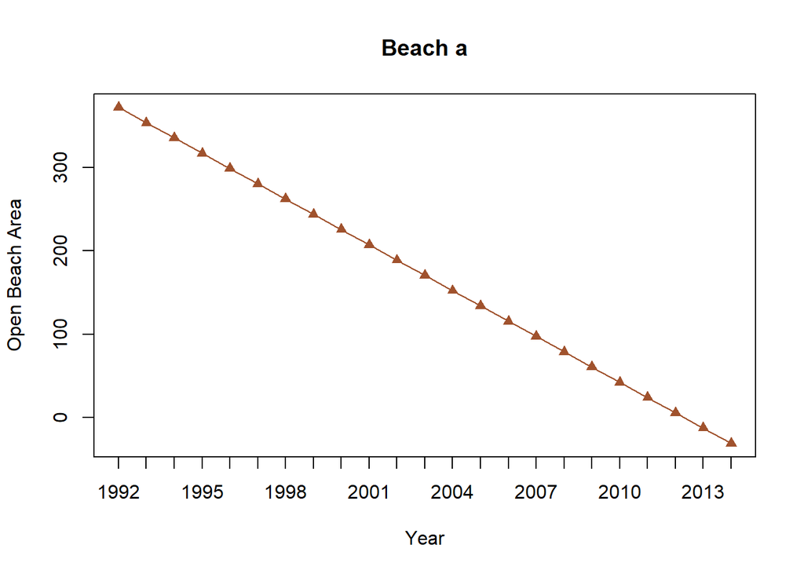

```r
x = 1992:2014

a <- 36945.73 + (- 18.36 * x)
b <- 36945.73 + (-18.36 + 17.04)*x + -34211.98
c <- 36945.73 + (-18.36 + 14.37)*x + -28776.11

plot(a, xlab = "Year", ylab = "Open Beach Area", type = "o", pch = 17, col = "sienna", xaxt = "n")
title(main = "Beach a")
axis(side = 1, at = 1:23, lab = c("1992", "1993", "1994", "1995", "1996", "1997", "1998",
                                  "1999", "2000", "2001", "2002", "2003", "2004", "2005", "2006", "2007", "2008", "2009",  "2010", "2011", "2012", "2013", "2014"))
```

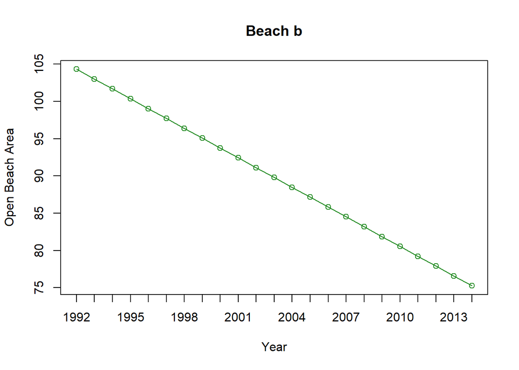

```r
plot(b, xlab = "Year", ylab = "Open Beach Area", type = "o", pch = 21, col = "forestgreen", xaxt = "n")
title(main = "Beach b")
axis(side = 1, at = 1:23, lab = c("1992", "1993", "1994", "1995", "1996", "1997", "1998",
                                  "1999", "2000", "2001", "2002", "2003", "2004", "2005", "2006", "2007", "2008", "2009",  "2010", "2011", "2012", "2013", "2014"))
```